```python
from google.colab import files
uploaded = files.upload()
```

```
Saving ExtraaLearn.csv to ExtraaLearn.csv
```

```python
# Libraries to help with reading and manipulating data
import pandas as pd
import numpy as np

# Libaries to help with data visualization
import matplotlib.pyplot as plt
import seaborn as sns

# Removes the limit for the number of displayed columns
pd.set_option("display.max_columns", None)
# Sets the limit for the number of displayed rows
pd.set_option("display.max_rows", 200)
# Setting the precision of floating numbers to 5 decimal points
pd.set_option("display.float_format", lambda x: "%.5f" % x)

# To tune model, get different metric scores, and split data
# Import various performance metrics for evaluating classification models
from sklearn.metrics import (
    f1_score,           # Harmonic mean of precision and recall, useful for imbalanced classes
    accuracy_score,     # Ratio of correctly predicted instances to total instances
    recall_score,       # Ability of the model to find all relevant instances (true positive rate)
    precision_score,    # Ability of the model to identify only relevant instances (positive predictive value)
    confusion_matrix,   # Table summarizing prediction results (true positives, false positives, etc.)
    roc_auc_score,      # Area under the Receiver Operating Characteristic curve, measuring the model's ability to distinguish between classes
    classification_report,  # Text report with precision, recall, F1-score for each class and overall
    precision_recall_curve  # Compute precision-recall pairs for different probability thresholds (useful for imbalanced datasets)
)
from sklearn import metrics # Performance evaluation

# Import necessary modules for model evaluation
from sklearn.model_selection import (
    train_test_split,    # Function to split data into training and testing sets
    StratifiedKFold,      # Cross-validation technique for maintaining class distribution
    cross_val_score      # Function to perform cross-validation and get scores
)

# To be used for data scaling and one hot encoding
from sklearn.preprocessing import StandardScaler, MinMaxScaler, OneHotEncoder

# To impute missing values
from sklearn.impute import SimpleImputer

# To build classification models
from sklearn.svm import SVC
from sklearn.tree import DecisionTreeClassifier
from sklearn.ensemble import RandomForestClassifier
from sklearn.linear_model import LogisticRegression


# For tuning the model
from sklearn.model_selection import GridSearchCV

# To supress warnings
import warnings
warnings.filterwarnings("ignore")
```

```python
# Loading the dataset
ExtraaLearn= pd.read_csv("ExtraaLearn.csv")
```

```python
# Checking the number of rows and columns in the data
print(f"There are:\n{ExtraaLearn.shape[1]} columns and {ExtraaLearn.shape[0]} rows")
```

```
There are:
15 columns and 4612 rows
```

Observations:

*There are 4612 observations and 15 columns in the dataset

Data Overview

```python
# Creating a copy of the data
data=ExtraaLearn.copy()
```

```python
# View the first 5 rows of the data
data.head()
```

|  | ID | age | current_occupation | first_interaction | profile_completed | website_visits | time_spent_on_website | page_views_per_visit | last_activity | print_media_type1 | print_media_type2 | digital_media | educational_channels | referral | status |
| --- | --- | --- | --- | --- | --- | --- | --- | --- | --- | --- | --- | --- | --- | --- | --- |
| 0 | EXT001 | 57 | Unemployed | Website | High | 7 | 1639 | 1.86100 | Website Activity | Yes | No | Yes | No | No | 1 |
| 1 | EXT002 | 56 | Professional | Mobile App | Medium | 2 | 83 | 0.32000 | Website Activity | No | No | No | Yes | No | 0 |
| 2 | EXT003 | 52 | Professional | Website | Medium | 3 | 330 | 0.07400 | Website Activity | No | No | Yes | No | No | 0 |
| 3 | EXT004 | 53 | Unemployed | Website | High | 4 | 464 | 2.05700 | Website Activity | No | No | No | No | No | 1 |
| 4 | EXT005 | 23 | Student | Website | High | 4 | 600 | 16.91400 | Email Activity | No | No | No | No | No | 0 |

```python
# View the last 5 rows of the data
data.tail()
```

|  | ID | age | current_occupation | first_interaction | profile_completed | website_visits | time_spent_on_website | page_views_per_visit | last_activity | print_media_type1 | print_media_type2 | digital_media | educational_channels | referral | status |
| --- | --- | --- | --- | --- | --- | --- | --- | --- | --- | --- | --- | --- | --- | --- | --- |
| 4607 | EXT4608 | 35 | Unemployed | Mobile App | Medium | 15 | 360 | 2.17000 | Phone Activity | No | No | No | Yes | No | 0 |
| 4608 | EXT4609 | 55 | Professional | Mobile App | Medium | 8 | 2327 | 5.39300 | Email Activity | No | No | No | No | No | 0 |
| 4609 | EXT4610 | 58 | Professional | Website | High | 2 | 212 | 2.69200 | Email Activity | No | No | No | No | No | 1 |
| 4610 | EXT4611 | 57 | Professional | Mobile App | Medium | 1 | 154 | 3.87900 | Website Activity | Yes | No | No | No | No | 0 |
| 4611 | EXT4612 | 55 | Professional | Website | Medium | 4 | 2290 | 2.07500 | Phone Activity | No | No | No | No | No | 0 |

```python
# Checking sample row of the data
data.sample(5)
```

|  | ID | age | current_occupation | first_interaction | profile_completed | website_visits | time_spent_on_website | page_views_per_visit | last_activity | print_media_type1 | print_media_type2 | digital_media | educational_channels | referral | status |
| --- | --- | --- | --- | --- | --- | --- | --- | --- | --- | --- | --- | --- | --- | --- | --- |
| 2139 | EXT2140 | 38 | Professional | Website | Medium | 4 | 1633 | 1.98700 | Website Activity | Yes | No | No | No | No | 1 |
| 227 | EXT228 | 48 | Unemployed | Website | Medium | 2 | 1942 | 13.07600 | Phone Activity | No | No | No | Yes | No | 0 |
| 2696 | EXT2697 | 21 | Student | Mobile App | High | 2 | 690 | 5.38600 | Email Activity | No | No | Yes | No | No | 1 |
| 788 | EXT789 | 50 | Professional | Mobile App | Medium | 5 | 1805 | 0.27000 | Email Activity | No | Yes | No | No | No | 0 |
| 4298 | EXT4299 | 32 | Professional | Website | High | 4 | 48 | 13.65600 | Email Activity | No | No | Yes | No | No | 1 |

```python
# Check and confirm the data types of the columns in the dataset
data.info()
```

```
<class 'pandas.core.frame.DataFrame'>
RangeIndex: 4612 entries, 0 to 4611
Data columns (total 15 columns):
 #   Column                 Non-Null Count  Dtype
---  ------                 --------------  -----
 0   ID                     4612 non-null   object
 1   age                    4612 non-null   int64
 2   current_occupation     4612 non-null   object
 3   first_interaction      4612 non-null   object
 4   profile_completed      4612 non-null   object
 5   website_visits         4612 non-null   int64
 6   time_spent_on_website  4612 non-null   int64
 7   page_views_per_visit   4612 non-null   float64
 8   last_activity          4612 non-null   object
 9   print_media_type1      4612 non-null   object
 10  print_media_type2      4612 non-null   object
 11  digital_media          4612 non-null   object
 12  educational_channels   4612 non-null   object
 13  referral               4612 non-null   object
 14  status                 4612 non-null   int64
dtypes: float64(1), int64(4), object(10)
memory usage: 540.6+ KB
```

Observations:

- There are no missing data in all the columns
- Five columns are numerical and the rest are object type.

Checking for duplicate values

```python
# Let's check for duplicate values in the data
data.duplicated().sum()
```

```
0
```

```python
data.isnull().sum()
```

|  | 0 |
| --- | --- |
| ID | 0 |
| age | 0 |
| current_occupation | 0 |
| first_interaction | 0 |
| profile_completed | 0 |
| website_visits | 0 |
| time_spent_on_website | 0 |
| page_views_per_visit | 0 |
| last_activity | 0 |
| print_media_type1 | 0 |
| print_media_type2 | 0 |
| digital_media | 0 |
| educational_channels | 0 |
| referral | 0 |
| status | 0 |

**dtype:** int64

```python
There are no duplicate or missing values in our dataset. There is a sufficient reason to continue with our analysis
```

Univariate analysis of numerical columns

```python
# Let's view the statistical summary of the numerical columns in the data, display only 2 values after decimal
desc = data.describe().T

# Pretty print with formatted values
print(desc.to_string(formatters={column: '{:.2f}'.format for column in desc.columns}))
```

```
                        count   mean    std   min    25%    50%     75%     max
age                   4612.00  46.20  13.16 18.00  36.00  51.00   57.00   63.00
website_visits        4612.00   3.57   2.83  0.00   2.00   3.00    5.00   30.00
time_spent_on_website 4612.00 724.01 743.83  0.00 148.75 376.00 1336.75 2537.00
page_views_per_visit  4612.00   3.03   1.97  0.00   2.08   2.79    3.76   18.43
status                4612.00   0.30   0.46  0.00   0.00   0.00    1.00    1.00
```

This table presents summary statistics for a dataset with 4,612 observations across five variables. The explanation is thus: age: 1.Mean age: 46.20 years ( The average age is 46 years) Standard deviation: 13.16 years Range: 18 to 63 years Median (50th percentile): 51 years Interquartile range: 36 to 57 years 2.website_visits: Mean visits: 3.57 ( The average website visit is approx 4 visits) Standard deviation: 2.83 Range: 0 to 30 visits Median: 3 visits Interquartile range: 2 to 5 visits 3.time_spent_on_website: Mean time: 724.01 (Average time spent on the website is 724 seconds) Standard deviation: 743.83 Range: 0 to 2,537 Median: 376.00 Interquartile range: 148.75 to 1,336.75 page_views_per_visit: 4.Mean views: 3.03 ( the average view is 3 times) Standard deviation: 1.97 Range: 0 to 18.43 Median: 2.79 Interquartile range: 2.08 to 3.76 5.status: This is a categorical variable coded as 0 and 1 Mean: 0.30 (30% of observations are coded as 1) Standard deviation: 0.46 Median: 0 (more than half of observations are coded as 0) Key observations: The age distribution is slightly left-skewed, with a median higher than the mean. Website visits and time spent show high variability, with some users spending much more time than others. Page views per visit are relatively consistent, with most users viewing 2-4 pages per visit. The status variable is binary, with 30% of observations in one category and 70% in the other.

Univariate analysis for categorical variables

```python
# Statistical description of categorical columns
data.describe(include=["object"]).T
```

|  | count | unique | top | freq |
| --- | --- | --- | --- | --- |
| ID | 4612 | 4612 | EXT001 | 1 |
| current_occupation | 4612 | 3 | Professional | 2616 |
| first_interaction | 4612 | 2 | Website | 2542 |
| profile_completed | 4612 | 3 | High | 2264 |
| last_activity | 4612 | 3 | Email Activity | 2278 |
| print_media_type1 | 4612 | 2 | No | 4115 |
| print_media_type2 | 4612 | 2 | No | 4379 |
| digital_media | 4612 | 2 | No | 4085 |
| educational_channels | 4612 | 2 | No | 3907 |
| referral | 4612 | 2 | No | 4519 |

Interpretations:

This table provides summary statistics for categorical variables in a dataset with 4,612 observations. The interpretation is thus: 1.ID: 4,612 unique values Example ID: EXT001 Each observation has a unique ID 2.current_occupation: There are 3 unique categories Most common: "Professional" (2,616 occurrences) 3.first_interaction: There are 2 categories Most common: "Website" (2,542 occurrences) 4.profile_completed: There are 3 categories Most common: "High" (2,264 occurrences) 5.last_activity: There 3 categories Most common: "Email Activity" (2,278 occurrences) 6.print_media_type1: There are 2 categories (Yes/No) Most common: "No" (4,115 occurrences) print_media_type2: There are 2 categories (Yes/No) Most common: "No" (4,379 occurrences) 7.digital_media: There are 2 categories (Yes/No) Most common: "No" (4,085 occurrences) 8.educational_channels: There are 2 categories (Yes/No) Most common: "No" (3,907 occurrences) 9.referral: There are 2 categories (Yes/No) Most common: "No" (4,519 occurrences)

```python
# Printing the % sub categories of each category
for i in data.describe(include=["object"]).columns: # Loop through columns containing string values
    print("Unique values in", i, "are :") # Print the column name
    print(data[i].value_counts()) # Print the count of each unique value in the column
    print("*" * 50) # Print a separator for better readability
```

```
Unique values in ID are :
ID
EXT001     1
EXT2884    1
EXT3080    1
EXT3079    1
EXT3078    1
          ..
EXT1537    1
EXT1536    1
EXT1535    1
EXT1534    1
EXT4612    1
Name: count, Length: 4612, dtype: int64
Unique values in current_occupation are :
current_occupation
Professional    2616
Unemployed      1441
Student          555
Name: count, dtype: int64
Unique values in first_interaction are :
first_interaction
Website       2542
Mobile App    2070
Name: count, dtype: int64
Unique values in profile_completed are :
profile_completed
High      2264
Medium    2241
Low        107
Name: count, dtype: int64
Unique values in last_activity are :
last_activity
Email Activity      2278
Phone Activity      1234
Website Activity    1100
Name: count, dtype: int64
Unique values in print_media_type1 are :
print_media_type1
No     4115
Yes     497
Name: count, dtype: int64
Unique values in print_media_type2 are :
print_media_type2
No     4379
Yes     233
Name: count, dtype: int64
Unique values in digital_media are :
digital_media
No     4085
Yes     527
Name: count, dtype: int64
Unique values in educational_channels are :
educational_channels
No     3907
Yes     705
Name: count, dtype: int64
Unique values in referral are :
referral
No     4519
Yes      93
Name: count, dtype: int64
```

Interpretations of above tables: This table provides a summary of the distribution of various categorical variables in a dataset. 1.Current Occupation: Majority are Professionals (2,616) Followed by Unemployed (1,441) Least are Students (555) 2.First Interaction: Slightly more users first interacted via Website (2,542) Compared to Mobile App (2,070) Profile Completion: Most profiles are either High (2,264) or Medium (2,241) completion Very few have Low completion (107) 3.Last Activity: Email Activity is most common (2,278) Followed by Phone Activity (1,234) Website Activity is least common (1,100) 4.Print Media Type 1: Vast majority did not engage (4,115 No vs 497 Yes) 5.Print Media Type 2: Even fewer engaged with this type (4,379 No vs 233 Yes) 6.Digital Media: Similar to print media, most did not engage (4,085 No vs 527 Yes) 7.Educational Channels: Again, majority did not engage (3,907 No vs 705 Yes) 8.Referral: Very few came through referrals (4,519 No vs 93 Yes) Observations: Most users are professionals who interact primarily through websites and email. There's a high rate of profile completion, suggesting engaged users. However, engagement with various media types (print, digital, educational) is generally low. The referral program seems particularly ineffective.

Data Pre-processing

```python
# ID consists of uniques ID for clients and hence will not add value to the modeling
data.drop(["ID"], axis=1, inplace=True)
```

Exploratory Data Analysis

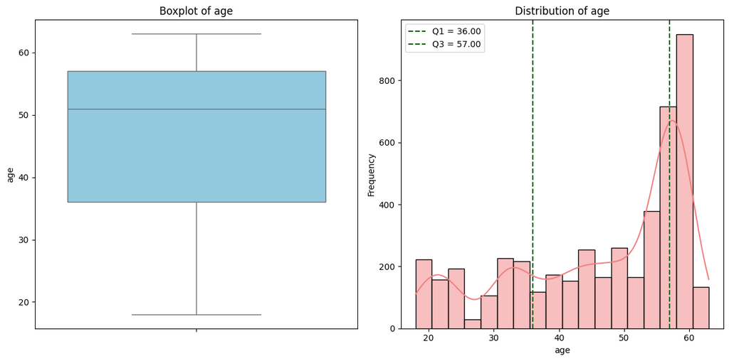

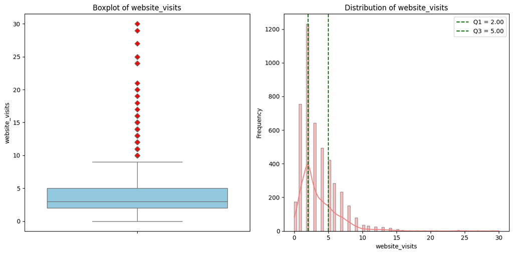

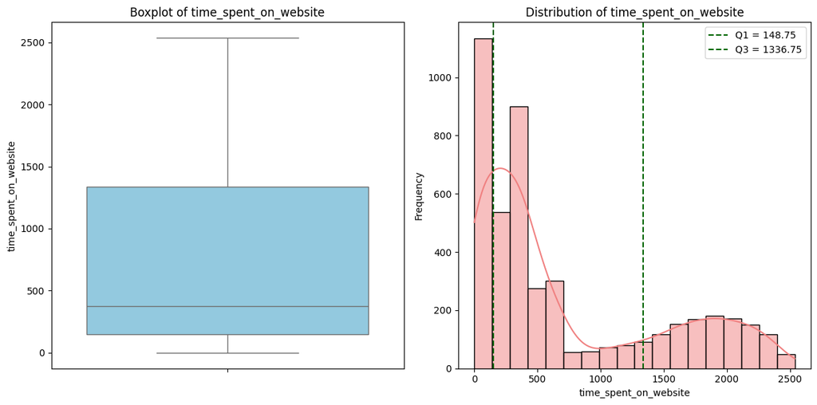

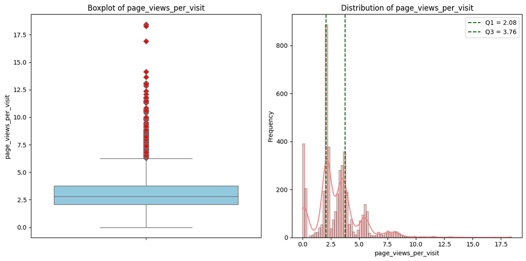

```python
# Create a list of numerical columns individually
numerical_columns = ['age', 'website_visits', 'time_spent_on_website', 'page_views_per_visit']

# Define colors for plots
boxplot_color = 'skyblue'
hist_color = 'lightcoral'
quartile_line_color = 'darkgreen'

# Iterate over numerical columns
for col in data[numerical_columns]: # Iterating over all the individual columns that are listed above

    # Create a new figure with two subplots
    plt.figure(figsize=(12, 6)) # setting the visuals siz

    # --- Boxplot ---
    plt.subplot(1, 2, 1)  # First subplot for boxplot
    sns.boxplot(data=data[col], color=boxplot_color, flierprops=dict(markerfacecolor='red', marker='D')) # Boxplot with red dots for outliers
    plt.title(f'Boxplot of {col}') # Title for the boxplot
    plt.ylabel(col) # Y-axis label

    # --- Histogram with KDE and Quartiles ---
    plt.subplot(1, 2, 2)  # Second subplot for histogram
    sns.histplot(data=data[col], kde=True, color=hist_color) # Histogram with KDE overlay
    plt.title(f'Distribution of {col}') # Title for the histogram
    plt.xlabel(col) # X-axis label
    plt.ylabel('Frequency') # Y-axis label

    # Add quartile lines
    q1, q3 = data[col].quantile([0.25, 0.75]) # Calculate quartiles
    plt.axvline(q1, color=quartile_line_color, linestyle='--', label=f'Q1 = {q1:.2f}') # Plot the first quartile line
    plt.axvline(q3, color=quartile_line_color, linestyle='--', label=f'Q3 = {q3:.2f}') # Plot the third quartile line
    plt.legend() # Add legend

    plt.tight_layout() # Adjust subplot spacing
    plt.show() # Display the plots
```

Interpretation of the above tables:

1.Websites per Visit The boxplot and distribution plot for websites per visit reveal: The median number of websites visited per session is approximately 2 to 3

The distribution is right-skewed, indicating that most visits involve a small number of websites, but some visits include a much larger number

The boxplot shows several outliers, with some visits involving 10 or more websites

Let's look at the plots individually

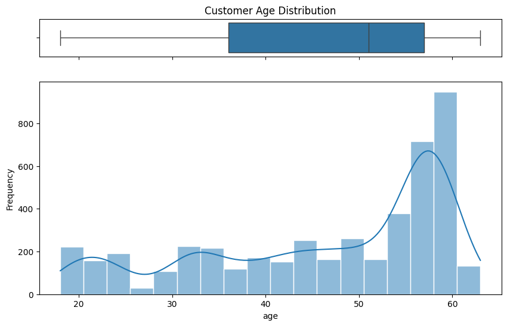

```python
# Create a figure with two subplots, one above the other
# sharex=True ensures that the x-axis is shared between the two plots
# gridspec_kw sets the height ratio of the subplots (0.15 for the boxplot, 0.85 for the histogram)
# figsize sets the overall size of the figure
f, (ax_box, ax_hist) = plt.subplots(2, sharex=True, gridspec_kw={'height_ratios': (.15, .85)}, figsize=(10, 6))

# Set the visual style of the plots to 'darkgrid', which provides a dark background with grid lines
sns.set_style("darkgrid")

# Create a box plot on the first subplot (ax_box)
# The box plot shows the distribution of 'Customer_Age' and highlights the median, quartiles, and potential outliers
sns.boxplot(data=data, x="age", ax=ax_box)

# Create a histogram with a kernel density estimate (KDE) overlay on the second subplot (ax_hist)
# The histogram shows the frequency distribution of 'Customer_Age'
# The KDE provides a smoothed line that represents the probability density function
sns.histplot(data=data, x="age", kde=True, ax=ax_hist)

# Remove the x-axis label from the box plot (ax_box) to avoid duplication since the histogram (ax_hist) will have the same label
ax_box.set(xlabel='')

# Optionally, you can also set a title or y-axis labels if needed
ax_box.set_title('Customer Age Distribution')
ax_hist.set_ylabel('Frequency')

# Display the combined plots
plt.show()
```

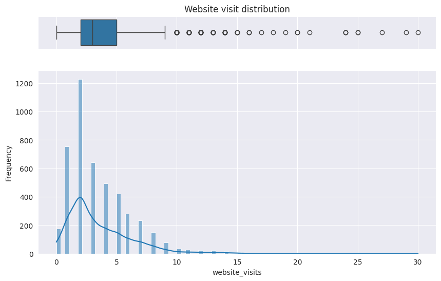

```python
# Create a figure with two subplots, one above the other
# sharex=True ensures that the x-axis is shared between the two plots
# gridspec_kw sets the height ratio of the subplots (0.15 for the boxplot, 0.85 for the histogram)
# figsize sets the overall size of the figure
f, (ax_box, ax_hist) = plt.subplots(2, sharex=True, gridspec_kw={'height_ratios': (.15, .85)}, figsize=(10, 6))

# Set the visual style of the plots to 'darkgrid', which provides a dark background with grid lines
sns.set_style("darkgrid")

# Create a box plot on the first subplot (ax_box)
# The box plot shows the distribution of 'Website visits' and highlights the median, quartiles, and potential outliers
sns.boxplot(data=data, x="website_visits", ax=ax_box)

# Create a histogram with a kernel density estimate (KDE) overlay on the second subplot (ax_hist)
# The histogram shows the frequency distribution of 'Customer_Age'
# The KDE provides a smoothed line that represents the probability density function
sns.histplot(data=data, x="website_visits", kde=True, ax=ax_hist)

# Remove the x-axis label from the box plot (ax_box) to avoid duplication since the histogram (ax_hist) will have the same label
ax_box.set(xlabel='')

# Optionally, you can also set a title or y-axis labels if needed
ax_box.set_title('Website visit distribution')
ax_hist.set_ylabel('Frequency')

# Display the combined plots
plt.show()
```

Bivariate analysis

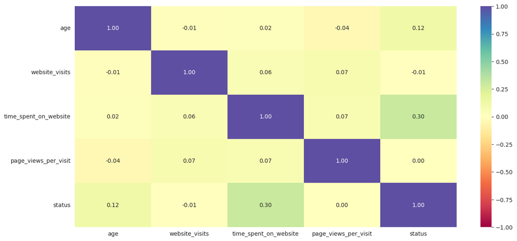

```python
numeric_data = data.select_dtypes(include=['float64', 'int64'])  # Select only the numeric columns
plt.figure(figsize=(15, 7)) # Set the figure size
sns.heatmap(numeric_data.corr(), annot=True, vmin=-1, vmax=1, fmt=".2f", cmap="Spectral") # Plot the heatmap with annotations
plt.show() # Display the heatmap
```

Correlation Analysis Age: Shows a weak positive correlation with status (0.12), suggesting older users might have a slightly different status. Negligible correlation with other variables. Website Visits: Very weak correlations with all other variables, indicating visits are relatively independent of age, time spent, and status. Time Spent on Website: Shows a moderate positive correlation with status (0.30), suggesting that more time spent might relate to a particular status. Weak correlations with other variables. Page Views per Visit: Very weak or no correlation with other variables, indicating page views per visit are largely independent. Status: As mentioned, has a moderate correlation with time spent on website (0.30), indicating a potential link between user status and engagement time. Key Insights Independence: Most variables show weak correlations, suggesting they operate independently. Engagement: Time spent on the website has the strongest correlation with status, which might indicate that users with certain statuses spend more time on the site. User Behavior: The weak correlations suggest diverse user behaviors, with no single factor strongly influencing another.

Status VS Age

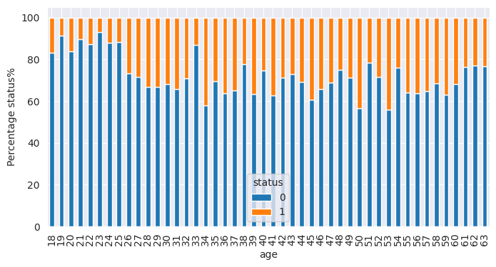

```python
(pd.crosstab(data['age'],data['status'],normalize='index')*100).plot(kind='bar',figsize=(8,4),stacked=True)
plt.ylabel('Percentage status%')
```

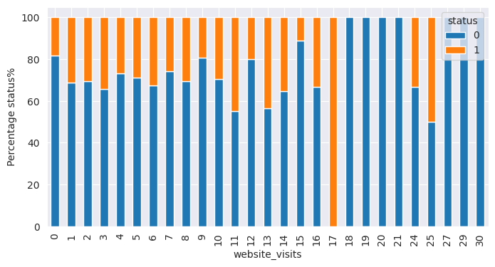

```python
(pd.crosstab(data['website_visits'],data['status'],normalize='index')*100).plot(kind='bar',figsize=(8,4),stacked=True)
plt.ylabel('Percentage status%')
```

The outliers?

```python
# Select only the numeric columns (float64 and int64 types) from the DataFrame 'data'
numeric_data = data.select_dtypes(include=['float64', 'int64'])

# Calculate the first quartile (Q1) for each numeric column
# Q1 represents the 25th percentile, which is the value below which 25% of the data falls
Q1 = numeric_data.quantile(0.25)

# Calculate the third quartile (Q3) for each numeric column
# Q3 represents the 75th percentile, which is the value below which 75% of the data falls
Q3 = numeric_data.quantile(0.75)

# Compute the Interquartile Range (IQR) for each numeric column
# IQR is the range between the first quartile (Q1) and the third quartile (Q3), capturing the middle 50% of the data
IQR = Q3 - Q1

# Determine the lower bound for outliers for each numeric column
# This is calculated as Q1 minus 1.5 times the IQR, marking the threshold below which data points are considered outliers
lower = Q1 - 1.5 * IQR

# Determine the upper bound for outliers for each numeric column
# This is calculated as Q3 plus 1.5 times the IQR, marking the threshold above which data points are considered outliers
upper = Q3 + 1.5 * IQR
```

```python
# Calculate Percentage of Outliers in Numerical Columns

(
    # Identify values outside the specified bounds
    (data.select_dtypes(include=["float64", "int64"]) < lower)  # Values below the lower bound
    | (data.select_dtypes(include=["float64", "int64"]) > upper)  # Values above the upper bound
# Sum the number of True values (outliers) per column, Divide by the total number of rows in the DataFrame, and Multiply by 100 to express as a percentage
).sum() / len(data) * 100
```

|  | 0 |
| --- | --- |
| age | 0.00000 |
| website_visits | 3.33912 |
| time_spent_on_website | 0.00000 |
| page_views_per_visit | 5.57242 |
| status | 0.00000 |

**dtype:** float64

Observations : The outliers are minimal in website visits and page views per visits. This represents a real world scenario. We will not remove the outliers.

*Separating the independent variables (X) and the dependent variable (Y)*

```python
# Features (X) include all columns
X = data

# Extract Target Variable (y)
y = data["status"]
```

*Splitting the data into 70% train and 30% test set*

Some classification problems can exhibit a large imbalance in the distribution of the target classes: for instance there could be several times more negative samples than positive samples. In such cases it is recommended to use the *stratified sampling* technique to ensure that relative class frequencies are approximately preserved in each train and validation fold.

```python
# Perform the Split
X_train, X_test, y_train, y_test = train_test_split(
    X,               # The feature matrix (all your predictor variables)
    y,               # The target variable (the thing you're trying to predict)
    test_size=0.3,   # Proportion of the data to include in the test split (30% in this case)
    random_state=1,  # Seed for the random number generator (ensures reproducibility)
    stratify=y       # Split data in a way that maintains the same proportion of classes in both sets
)
```

```python
# Visualize Distribution of Categorical Features
```

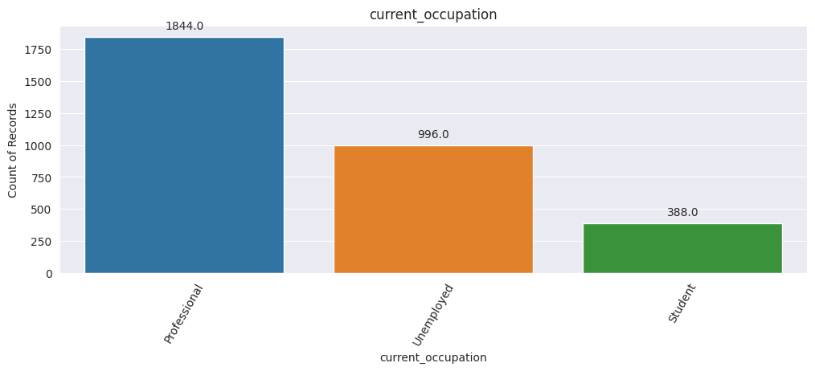

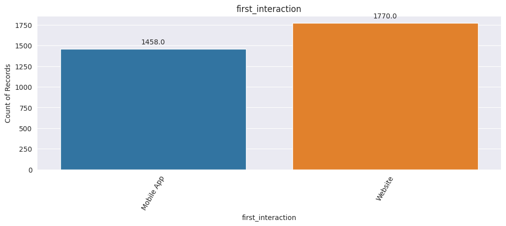

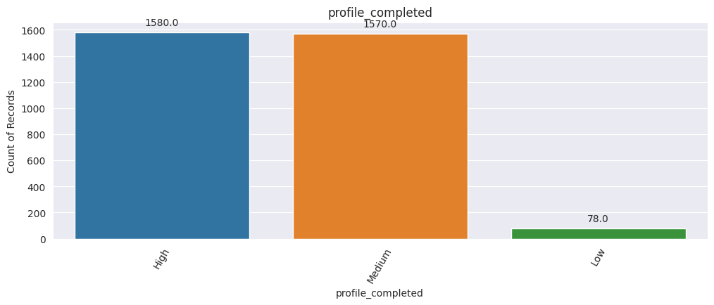

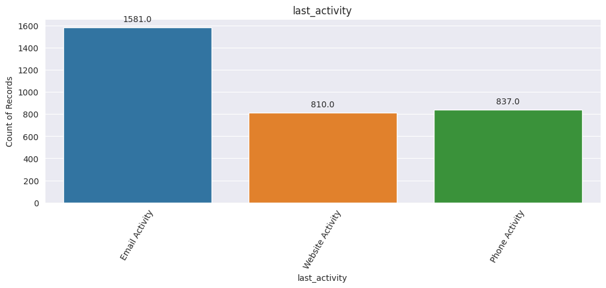

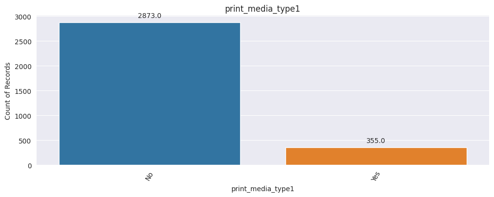

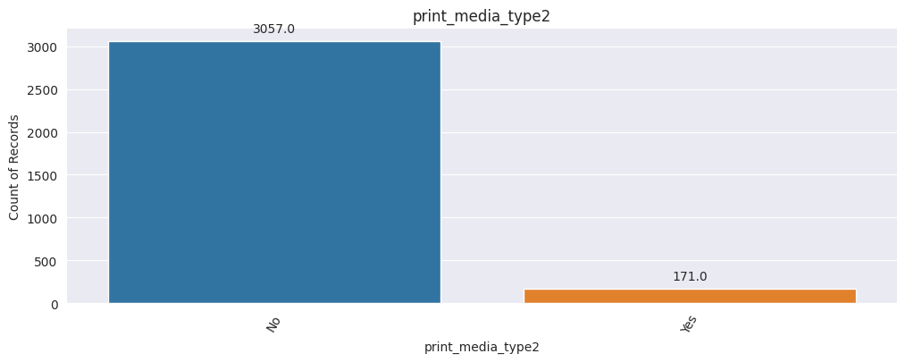

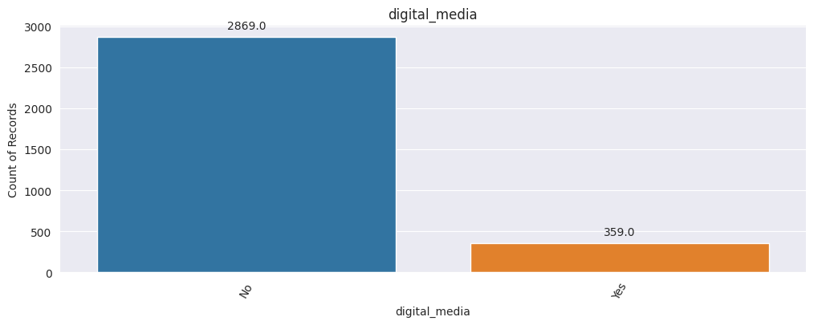

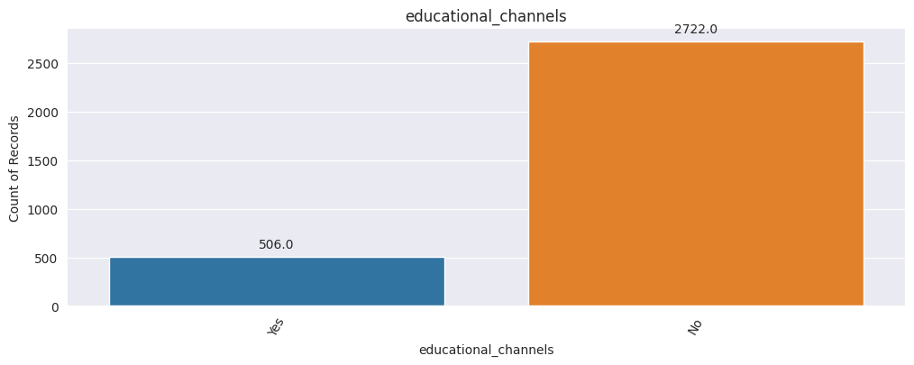

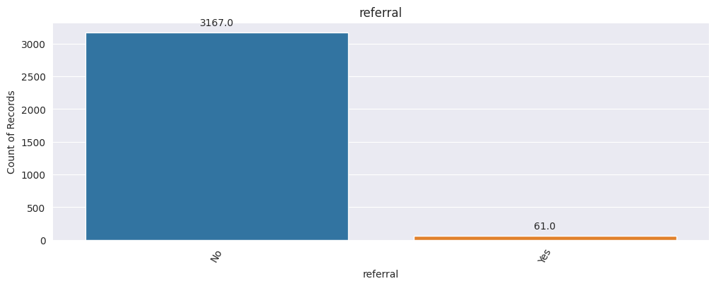

```python
# Iterate over categorical and object columns in X_train
for i in X_train.select_dtypes(include=["object", "category"]).columns:
    plt.figure(figsize=(12, 4)) # Create a new figure for each plot

    # Create a countplot using seaborn
    sns.countplot(
        x=i,              # The column to plot on the x-axis
        data=X_train,     # The DataFrame containing the data
        hue=i             # Split the bars based on the categories within the column
    )

    # Annotate bar plots with count values
    for p in plt.gca().patches:  # Iterate through the patches (bars) in the plot
        height = p.get_height() # Get the height (count) of the bar

        # Add the count as text above the bar
        plt.gca().annotate(f'{height}',
                        (p.get_x() + p.get_width() / 2., height),  # Position the text above the center of the bar
                        ha='center', va='center',                   # Horizontal and vertical alignment
                        xytext=(0, 10), textcoords='offset points')  # Adjust text position slightly above the bar
    plt.title(i) # Add a title to the plot
    plt.xticks(rotation=60) # Rotate x-axis labels to improve readability
    plt.ylabel("Count of Records") # Set the y-axis label
    plt.show() # Display the plot
```

Plotting Countplot to the Categorical Columns in X_test (Test Data)

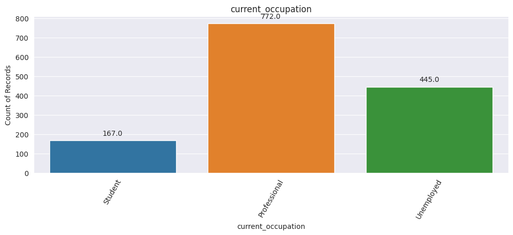

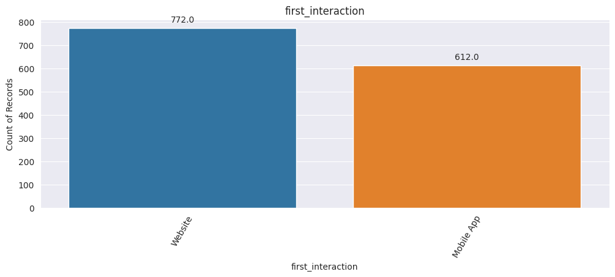

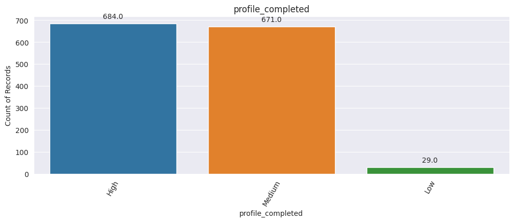

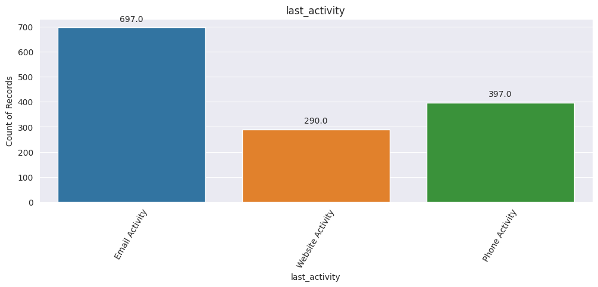

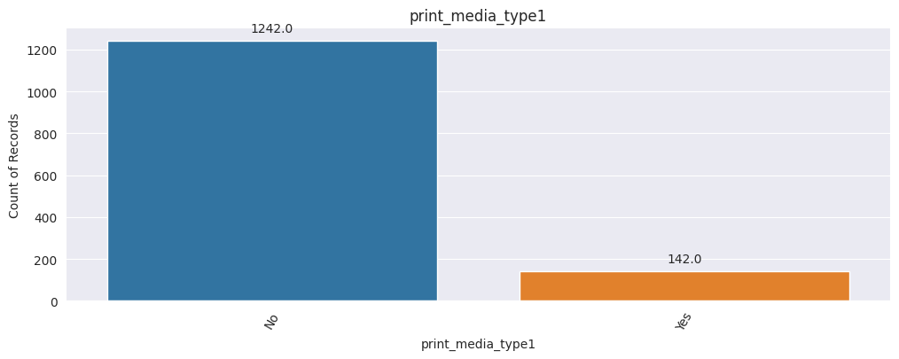

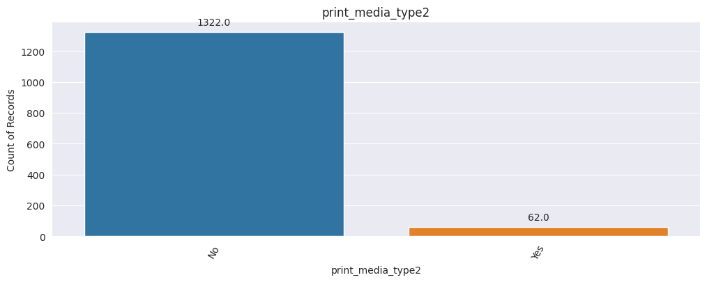

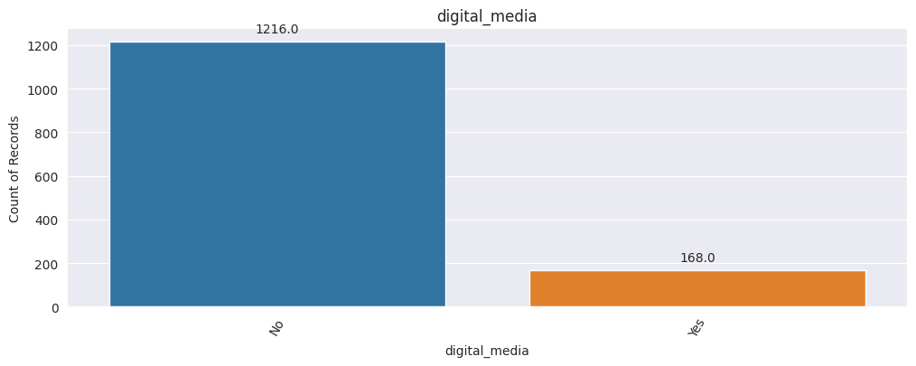

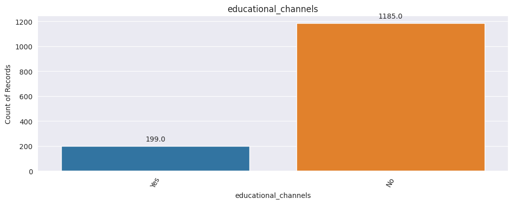

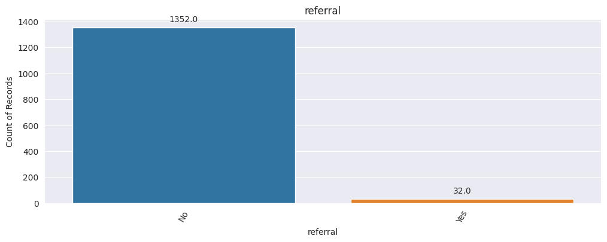

```python
# Visualize Distribution of Categorical Features

# Iterate over categorical and object columns in X_test
for i in X_test.select_dtypes(include=["object", "category"]).columns:
    plt.figure(figsize=(12, 4)) # Create a new figure for each plot

    # Create a countplot using seaborn
    sns.countplot(
        x=i,              # The column to plot on the x-axis
        data=X_test,     # The DataFrame containing the data
        hue=i             # Split the bars based on the categories within the column
    )

    # Annotate bar plots with count values
    for p in plt.gca().patches:  # Iterate through the patches (bars) in the plot
        height = p.get_height() # Get the height (count) of the bar

        # Add the count as text above the bar
        plt.gca().annotate(f'{height}',
                        (p.get_x() + p.get_width() / 2., height),  # Position the text above the center of the bar
                        ha='center', va='center',                   # Horizontal and vertical alignment
                        xytext=(0, 10), textcoords='offset points')  # Adjust text position slightly above the bar
    plt.title(i) # Add a title to the plot
    plt.xticks(rotation=60) # Rotate x-axis labels to improve readability
    plt.ylabel("Count of Records") # Set the y-axis label
    plt.show() # Display the plot
```

Encoding of categorical variables

```python
# Prepare Categorical Features for Modeling

# Create Dummy Variables for Training Data
X_train = pd.get_dummies(
    X_train,        # The DataFrame containing your categorical features
    drop_first=True, # Drop the first dummy variable for each categorical feature
    dtype=int        # Ensure dummy variables are integers (0 or 1)
)

# Display the first few rows of the transformed data
X_train.head()


# Create Dummy Variables for Testing Data (Matching Training Transformation)
X_test = pd.get_dummies(
    X_test,         # The DataFrame containing your categorical features in the test set
    drop_first=True,  # Must match the drop_first used for the training data
    dtype=int         # Must match the dtype used for the training data
)

# Display the first few rows of the transformed test data
X_test.head()
```

|  | age | website_visits | time_spent_on_website | page_views_per_visit | status | current_occupation_Student | current_occupation_Unemployed | first_interaction_Website | profile_completed_Low | profile_completed_Medium | last_activity_Phone Activity | last_activity_Website Activity | print_media_type1_Yes | print_media_type2_Yes | digital_media_Yes | educational_channels_Yes | referral_Yes |
| --- | --- | --- | --- | --- | --- | --- | --- | --- | --- | --- | --- | --- | --- | --- | --- | --- | --- |
| 2362 | 24 | 2 | 1445 | 2.08500 | 1 | 1 | 0 | 1 | 0 | 0 | 0 | 0 | 0 | 0 | 0 | 1 | 0 |
| 4206 | 19 | 3 | 562 | 2.21200 | 0 | 1 | 0 | 1 | 0 | 1 | 0 | 1 | 0 | 0 | 0 | 0 | 0 |
| 2835 | 24 | 8 | 2114 | 6.80800 | 0 | 1 | 0 | 1 | 0 | 1 | 1 | 0 | 0 | 0 | 0 | 0 | 0 |
| 4229 | 57 | 1 | 230 | 3.64000 | 0 | 0 | 0 | 0 | 0 | 1 | 0 | 0 | 0 | 0 | 0 | 0 | 0 |
| 3006 | 37 | 5 | 365 | 3.88900 | 0 | 0 | 0 | 0 | 0 | 1 | 0 | 1 | 0 | 0 | 0 | 0 | 0 |

Observation : after encoding there are 17 columns